# Testing Differences in Group Means

Ryan Safner

ECON 480 - Econometrics

We want to run a hypothesis test for the difference $(d)$ in these two population means:
$$\textcolor{blue}{\mu_M}-\textcolor{red}{\mu_W}=d_0$$

Our null hypothesis is that there is *no* statistically significant difference. Let’s also have a two-sided alternative hypothesis, simply that there *is* a difference (positive or negative).

- $\textcolor{magenta}{H_0}: d=0$
- $\textcolor{teal}{H_1}: d \neq 0$

Note a logical one-sided alternative would be $H_2: d > 0$, i.e. men earn more than women

### The Sampling Distribution of $d$

We then estimate ($\textcolor{blue}{\mu_M}-\textcolor{red}{\mu_W}$) with the sample ($\textcolor{blue}{\bar{Y}_M}-\textcolor{red}{\bar{Y}_W}$).

We would then run a **t-test** and calculate the **test-statistic** for the difference in means. The formula for the test statistic is:

$$t = \frac{(\textcolor{blue}{\bar{Y_M}}-\textcolor{red}{\bar{Y_W}})-d_0}{\sqrt{\frac{\textcolor{blue}{s_M}^2}{\textcolor{blue}{n_M}}+\frac{\textcolor{red}{s_W}^2}{\textcolor{red}{n_W}}}}$$

We then compare $t$ against the critical value $t^*$, or calculate the $p$-value $P(T>t)$ as usual to determine if we have sufficient evidence to reject $H_0$

```r
# Our data comes from WAGE1.dta which you can find in Blackboard under data

# Load WAGE1 as wages
library("foreign") # to load .dta Stata files
wages<-read.dta("../Data/WAGE1.dta")
# there's a lot of variables in wages, let's only look at wage and female for now
wages<-subset(wages, select=c("wage","female"))

# just get a sense of the data

head(wages)
```

|  | wage | female |
| --- | --- | --- |
| 1 | 3.10 | 1 |
| 2 | 3.24 | 1 |
| 3 | 3.00 | 0 |
| 4 | 6.00 | 0 |
| 5 | 5.30 | 0 |
| 6 | 8.75 | 0 |

```r
# we now want to look at the data under certain CONDITIONS
# conditionals require subsetting data with square brackets []
# such as: data[df$variable==condition]

# look at average wage for men
summary(wages$wage[wages$female==0])
```

```
##    Min. 1st Qu.  Median    Mean 3rd Qu.    Max.
##   1.500   4.143   6.000   7.099   8.765  24.980
```

```r
sd(wages$wage[wages$female==0]) # get sd
```

```
## [1] 4.160858
```

```r
# look at average wage for women
summary(wages$wage[wages$female==1])
```

```
##    Min. 1st Qu.  Median    Mean 3rd Qu.    Max.
##   0.530   3.000   3.750   4.588   5.510  21.630
```

```r
sd(wages$wage[wages$female==1]) # get sd
```

```
## [1] 2.529363
```

So our data is telling us that male and female average hourly earnings are distributed as such:

$$\begin{align*}
\bar{Y}_M &\sim N(7.10,4.16)\\
\bar{Y}_W &\sim N(4.59,2.53)\\
\end{align*}$$

We can plot this to see visually. There is a lot of overlap in the two distributions, but the male average is higher than the female average, and there is also a lot more variation in males than females, noticeably the male distribution skews further to the right.

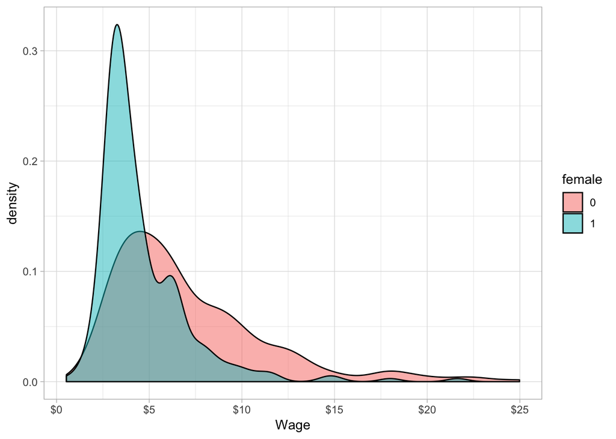

```r
wages$female<-as.factor(wages$female)

library("ggplot2")
ggplot(data=wages,aes(x=wage,fill=female))+
  geom_density(alpha=0.5)+
  scale_x_continuous(seq(0,25,5),name="Wage",labels=scales::dollar)+
  theme_light()
```

So the sampling distribution of the difference in group means is distributed:
$$\bar{d} \sim N(2.51,0.29)$$

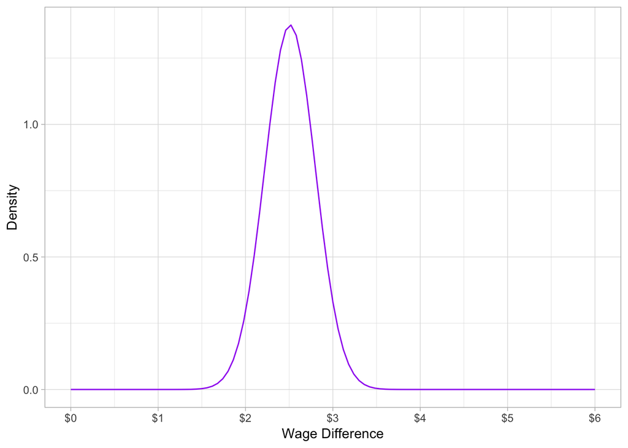

```r
ggplot(data.frame(x=0:6),aes(x=x))+
  stat_function(fun=dnorm, args=list(mean=2.51, sd=0.29), color="purple")+
  ylab("Density")+
  scale_x_continuous(seq(0,6,1),name="Wage Difference",labels=scales::dollar)+
  theme_light()
```

Now we the **$t$-test** like any other:

$$\begin{align*}
t&=\frac{\text{estimate}-\text{null hypothesis}}{\text{standard error of the estimate}}\\
&=\frac{d-0}{SE(d)}\\
&=\frac{2.51-0}{0.29}\\
&=8.66\\
\end{align*}$$

```r
pt(8.66,456.33, lower.tail=FALSE)
```

```
## [1] 4.102729e-17
```

### The $t$-test in `R`

```r
t.test(wage~female, data=wages, var.equal=FALSE)
```

```
##
##  Welch Two Sample t-test
##
## data:  wage by female
## t = 8.44, df = 456.33, p-value = 4.243e-16
## alternative hypothesis: true difference in means is not equal to 0
## 95 percent confidence interval:
##  1.926971 3.096690
## sample estimates:
## mean in group 0 mean in group 1
##        7.099489        4.587659
```

```r
reg<-lm(wage~female, data=wages)
summary(reg)
```

```
##
## Call:
## lm(formula = wage ~ female, data = wages)
##
## Residuals:
##     Min      1Q  Median      3Q     Max
## -5.5995 -1.8495 -0.9877  1.4260 17.8805
##
## Coefficients:
##             Estimate Std. Error t value Pr(>|t|)
## (Intercept)   7.0995     0.2100  33.806  < 2e-16 ***
## female1      -2.5118     0.3034  -8.279 1.04e-15 ***
## ---
## Signif. codes:  0 '***' 0.001 '**' 0.01 '*' 0.05 '.' 0.1 ' ' 1
##
## Residual standard error: 3.476 on 524 degrees of freedom
## Multiple R-squared:  0.1157, Adjusted R-squared:  0.114
## F-statistic: 68.54 on 1 and 524 DF,  p-value: 1.042e-15
```